# Risk Factor Analysis

## Outcome Variable

**Outcome Variable:** s03rec24

## Predictor Variables

**Intervention Variable:** mage

**Adjustment Set:**

unadjusted

## Stratifying Variables

The analysis was stratified on these variable(s):

- studyid
- country

## Data Summary

| studyid | country | A | n | nA | nAY0 | nAY1 |
| --- | --- | --- | --- | --- | --- | --- |
| ki0047075b-MAL-ED | BANGLADESH | <20 | 241 | 32 | 31 | 1 |
| ki0047075b-MAL-ED | BANGLADESH | [20-25) | 241 | 78 | 73 | 5 |
| ki0047075b-MAL-ED | BANGLADESH | [25-30) | 241 | 89 | 84 | 5 |
| ki0047075b-MAL-ED | BANGLADESH | >=30 | 241 | 42 | 42 | 0 |
| ki0047075b-MAL-ED | BRAZIL | <20 | 220 | 42 | 37 | 5 |
| ki0047075b-MAL-ED | BRAZIL | [20-25) | 220 | 69 | 62 | 7 |
| ki0047075b-MAL-ED | BRAZIL | [25-30) | 220 | 59 | 52 | 7 |
| ki0047075b-MAL-ED | BRAZIL | >=30 | 220 | 50 | 46 | 4 |
| ki0047075b-MAL-ED | INDIA | <20 | 242 | 34 | 28 | 6 |
| ki0047075b-MAL-ED | INDIA | [20-25) | 242 | 104 | 97 | 7 |
| ki0047075b-MAL-ED | INDIA | [25-30) | 242 | 83 | 80 | 3 |
| ki0047075b-MAL-ED | INDIA | >=30 | 242 | 21 | 19 | 2 |
| ki0047075b-MAL-ED | NEPAL | <20 | 237 | 4 | 3 | 1 |
| ki0047075b-MAL-ED | NEPAL | [20-25) | 237 | 60 | 57 | 3 |
| ki0047075b-MAL-ED | NEPAL | [25-30) | 237 | 127 | 119 | 8 |
| ki0047075b-MAL-ED | NEPAL | >=30 | 237 | 46 | 43 | 3 |
| ki0047075b-MAL-ED | PERU | <20 | 276 | 77 | 67 | 10 |
| ki0047075b-MAL-ED | PERU | [20-25) | 276 | 79 | 73 | 6 |
| ki0047075b-MAL-ED | PERU | [25-30) | 276 | 60 | 52 | 8 |
| ki0047075b-MAL-ED | PERU | >=30 | 276 | 60 | 55 | 5 |
| ki0047075b-MAL-ED | SOUTH AFRICA | <20 | 296 | 47 | 44 | 3 |
| ki0047075b-MAL-ED | SOUTH AFRICA | [20-25) | 296 | 94 | 85 | 9 |
| ki0047075b-MAL-ED | SOUTH AFRICA | [25-30) | 296 | 53 | 46 | 7 |
| ki0047075b-MAL-ED | SOUTH AFRICA | >=30 | 296 | 102 | 90 | 12 |
| ki0047075b-MAL-ED | TANZANIA, UNITED REPUBLIC OF | <20 | 248 | 15 | 15 | 0 |
| ki0047075b-MAL-ED | TANZANIA, UNITED REPUBLIC OF | [20-25) | 248 | 62 | 61 | 1 |
| ki0047075b-MAL-ED | TANZANIA, UNITED REPUBLIC OF | [25-30) | 248 | 68 | 68 | 0 |
| ki0047075b-MAL-ED | TANZANIA, UNITED REPUBLIC OF | >=30 | 248 | 103 | 102 | 1 |
| ki1000108-CMC-V-BCS-2002 | INDIA | <20 | 370 | 34 | 29 | 5 |
| ki1000108-CMC-V-BCS-2002 | INDIA | [20-25) | 370 | 186 | 174 | 12 |
| ki1000108-CMC-V-BCS-2002 | INDIA | [25-30) | 370 | 107 | 103 | 4 |
| ki1000108-CMC-V-BCS-2002 | INDIA | >=30 | 370 | 43 | 41 | 2 |
| ki1000108-IRC | INDIA | <20 | 410 | 37 | 32 | 5 |
| ki1000108-IRC | INDIA | [20-25) | 410 | 221 | 199 | 22 |
| ki1000108-IRC | INDIA | [25-30) | 410 | 123 | 109 | 14 |
| ki1000108-IRC | INDIA | >=30 | 410 | 29 | 26 | 3 |
| ki1000109-EE | PAKISTAN | <20 | 123 | 0 | 0 | 0 |
| ki1000109-EE | PAKISTAN | [20-25) | 123 | 7 | 7 | 0 |
| ki1000109-EE | PAKISTAN | [25-30) | 123 | 42 | 42 | 0 |
| ki1000109-EE | PAKISTAN | >=30 | 123 | 74 | 74 | 0 |
| ki1017093b-PROVIDE | BANGLADESH | <20 | 686 | 84 | 79 | 5 |
| ki1017093b-PROVIDE | BANGLADESH | [20-25) | 686 | 275 | 267 | 8 |
| ki1017093b-PROVIDE | BANGLADESH | [25-30) | 686 | 207 | 198 | 9 |
| ki1017093b-PROVIDE | BANGLADESH | >=30 | 686 | 120 | 113 | 7 |
| ki1066203-TanzaniaChild2 | TANZANIA, UNITED REPUBLIC OF | <20 | 2188 | 149 | 149 | 0 |
| ki1066203-TanzaniaChild2 | TANZANIA, UNITED REPUBLIC OF | [20-25) | 2188 | 692 | 691 | 1 |
| ki1066203-TanzaniaChild2 | TANZANIA, UNITED REPUBLIC OF | [25-30) | 2188 | 750 | 749 | 1 |
| ki1066203-TanzaniaChild2 | TANZANIA, UNITED REPUBLIC OF | >=30 | 2188 | 597 | 597 | 0 |
| ki1101329-Keneba | GAMBIA | <20 | 2411 | 341 | 313 | 28 |
| ki1101329-Keneba | GAMBIA | [20-25) | 2411 | 617 | 562 | 55 |
| ki1101329-Keneba | GAMBIA | [25-30) | 2411 | 538 | 506 | 32 |
| ki1101329-Keneba | GAMBIA | >=30 | 2411 | 915 | 863 | 52 |
| ki1113344-GMS-Nepal | NEPAL | <20 | 593 | 120 | 112 | 8 |
| ki1113344-GMS-Nepal | NEPAL | [20-25) | 593 | 207 | 200 | 7 |
| ki1113344-GMS-Nepal | NEPAL | [25-30) | 593 | 177 | 174 | 3 |
| ki1113344-GMS-Nepal | NEPAL | >=30 | 593 | 89 | 88 | 1 |

The following strata were considered:

- studyid: ki0047075b-MAL-ED, country: BANGLADESH
- studyid: ki0047075b-MAL-ED, country: BRAZIL
- studyid: ki0047075b-MAL-ED, country: INDIA
- studyid: ki0047075b-MAL-ED, country: NEPAL
- studyid: ki0047075b-MAL-ED, country: PERU
- studyid: ki0047075b-MAL-ED, country: SOUTH AFRICA
- studyid: ki0047075b-MAL-ED, country: TANZANIA, UNITED REPUBLIC OF
- studyid: ki1000108-CMC-V-BCS-2002, country: INDIA
- studyid: ki1000108-IRC, country: INDIA
- studyid: ki1000109-EE, country: PAKISTAN
- studyid: ki1017093b-PROVIDE, country: BANGLADESH
- studyid: ki1066203-TanzaniaChild2, country: TANZANIA, UNITED REPUBLIC OF
- studyid: ki1101329-Keneba, country: GAMBIA
- studyid: ki1113344-GMS-Nepal, country: NEPAL

### Dropped Strata

Some strata were dropped due to rare outcomes:

- studyid: ki0047075b-MAL-ED, country: BANGLADESH
- studyid: ki0047075b-MAL-ED, country: BRAZIL
- studyid: ki0047075b-MAL-ED, country: INDIA
- studyid: ki0047075b-MAL-ED, country: NEPAL
- studyid: ki0047075b-MAL-ED, country: SOUTH AFRICA
- studyid: ki0047075b-MAL-ED, country: TANZANIA, UNITED REPUBLIC OF
- studyid: ki1000108-CMC-V-BCS-2002, country: INDIA
- studyid: ki1000108-IRC, country: INDIA
- studyid: ki1000109-EE, country: PAKISTAN
- studyid: ki1066203-TanzaniaChild2, country: TANZANIA, UNITED REPUBLIC OF
- studyid: ki1113344-GMS-Nepal, country: NEPAL

## Methods Detail

We’re interested in the causal parameters $E[Y_a]$ for all values of $a \in \mathcal{A}$. These parameters represent the mean outcome if, possibly contrary to fact, we intervened to set all units to have $A=a$. Under the randomization and positivity assumptions, these are identified by the statistical parameters $\psi_a=E_W[E_{Y|A,W}(Y|A=a,W)]$. In addition, we’re interested in the mean of $Y$, $E[Y]$ under no intervention (the observed mean). We will estimate these parameters by using SuperLearner to fit the relevant likelihood factors – $E_{Y|A,W}(Y|A=a,W)$ and $p(A=a|W)$, and then updating our likelihood fit using a joint TMLE.

For unadjusted analyses ($W=\{\}$), initial likelihoods were estimated using Lrnr_glm to estimate the simple $E(Y|A)$ and Lrnr_mean to estimate $p(A)$. For adjusted analyses, a small library containing Lrnr_glmnet, Lrnr_xgboost, and Lrnr_mean was used.

Having estimated these parameters, we will then use the delta method to estimate relative risks and attributable risks relative to a prespecified baseline level of $A$.

# Results Detail

## Results Plots

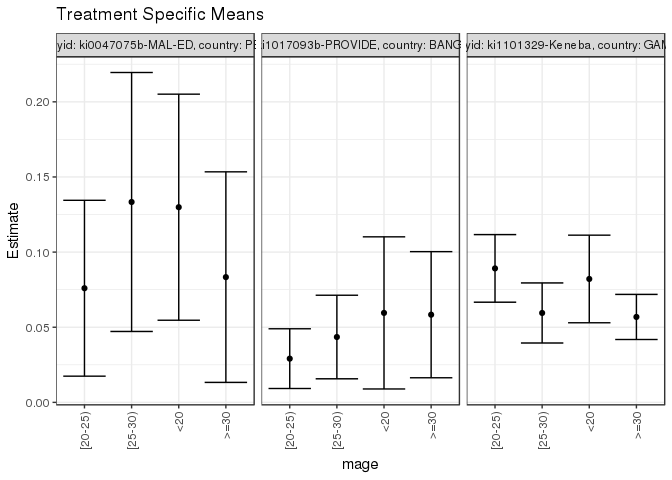

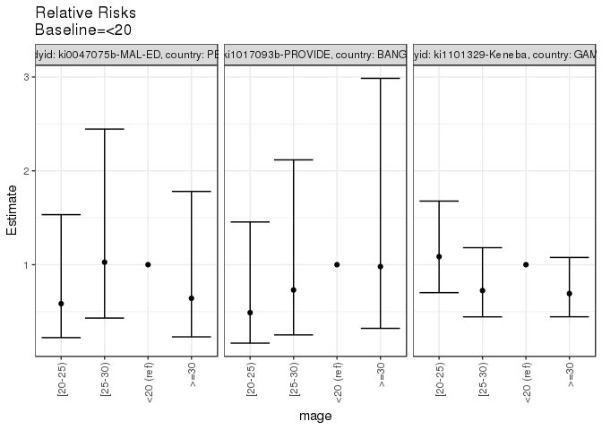

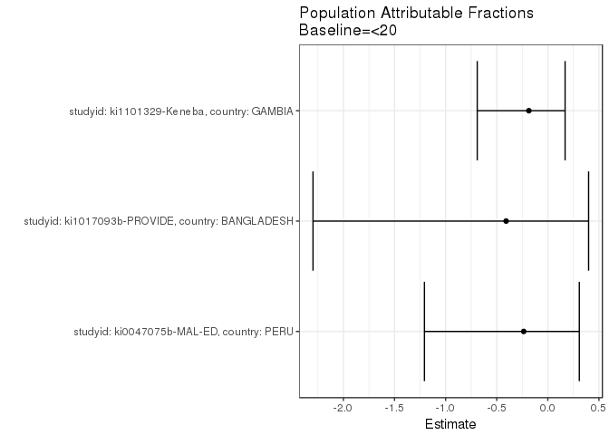

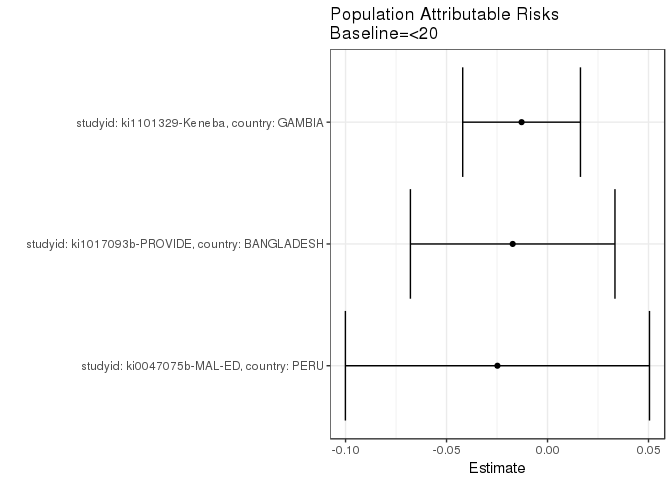

## Results Table

### Parameter: TSM

| studyid | country | intervention_level | baseline_level | estimate | ci_lower | ci_upper |
| --- | --- | --- | --- | --- | --- | --- |
| ki0047075b-MAL-ED | PERU | <20 | NA | 0.1298701 | 0.0546494 | 0.2050909 |
| ki0047075b-MAL-ED | PERU | [20-25) | NA | 0.0759494 | 0.0174255 | 0.1344732 |
| ki0047075b-MAL-ED | PERU | [25-30) | NA | 0.1333333 | 0.0471633 | 0.2195033 |
| ki0047075b-MAL-ED | PERU | >=30 | NA | 0.0833333 | 0.0132724 | 0.1533942 |
| ki1017093b-PROVIDE | BANGLADESH | <20 | NA | 0.0595238 | 0.0088895 | 0.1101581 |
| ki1017093b-PROVIDE | BANGLADESH | [20-25) | NA | 0.0290909 | 0.0092132 | 0.0489686 |
| ki1017093b-PROVIDE | BANGLADESH | [25-30) | NA | 0.0434783 | 0.0156771 | 0.0712794 |
| ki1017093b-PROVIDE | BANGLADESH | >=30 | NA | 0.0583333 | 0.0163689 | 0.1002978 |
| ki1101329-Keneba | GAMBIA | <20 | NA | 0.0821114 | 0.0529669 | 0.1112560 |
| ki1101329-Keneba | GAMBIA | [20-25) | NA | 0.0891410 | 0.0666525 | 0.1116295 |
| ki1101329-Keneba | GAMBIA | [25-30) | NA | 0.0594796 | 0.0394895 | 0.0794697 |
| ki1101329-Keneba | GAMBIA | >=30 | NA | 0.0568306 | 0.0418264 | 0.0718348 |

### Parameter: E(Y)

| studyid | country | intervention_level | baseline_level | estimate | ci_lower | ci_upper |
| --- | --- | --- | --- | --- | --- | --- |
| ki0047075b-MAL-ED | PERU | NA | NA | 0.1050725 | 0.1019663 | 0.1081786 |
| ki1017093b-PROVIDE | BANGLADESH | NA | NA | 0.0422741 | 0.0413518 | 0.0431963 |
| ki1101329-Keneba | GAMBIA | NA | NA | 0.0692659 | 0.0686950 | 0.0698368 |

### Parameter: RR

| studyid | country | intervention_level | baseline_level | estimate | ci_lower | ci_upper |
| --- | --- | --- | --- | --- | --- | --- |
| ki0047075b-MAL-ED | PERU | <20 | <20 | 1.0000000 | 1.0000000 | 1.000000 |
| ki0047075b-MAL-ED | PERU | [20-25) | <20 | 0.5848101 | 0.2230321 | 1.533424 |
| ki0047075b-MAL-ED | PERU | [25-30) | <20 | 1.0266667 | 0.4310543 | 2.445271 |
| ki0047075b-MAL-ED | PERU | >=30 | <20 | 0.6416667 | 0.2311664 | 1.781125 |
| ki1017093b-PROVIDE | BANGLADESH | <20 | <20 | 1.0000000 | 1.0000000 | 1.000000 |
| ki1017093b-PROVIDE | BANGLADESH | [20-25) | <20 | 0.4887273 | 0.1641368 | 1.455215 |
| ki1017093b-PROVIDE | BANGLADESH | [25-30) | <20 | 0.7304348 | 0.2520074 | 2.117140 |
| ki1017093b-PROVIDE | BANGLADESH | >=30 | <20 | 0.9800000 | 0.3216581 | 2.985779 |
| ki1101329-Keneba | GAMBIA | <20 | <20 | 1.0000000 | 1.0000000 | 1.000000 |
| ki1101329-Keneba | GAMBIA | [20-25) | <20 | 1.0856101 | 0.7023526 | 1.678002 |
| ki1101329-Keneba | GAMBIA | [25-30) | <20 | 0.7243760 | 0.4443008 | 1.181003 |
| ki1101329-Keneba | GAMBIA | >=30 | <20 | 0.6921155 | 0.4446947 | 1.077197 |

### Parameter: PAR

| studyid | country | intervention_level | baseline_level | estimate | ci_lower | ci_upper |
| --- | --- | --- | --- | --- | --- | --- |
| ki0047075b-MAL-ED | PERU | <20 | NA | -0.0247977 | -0.1000825 | 0.0504872 |
| ki1017093b-PROVIDE | BANGLADESH | <20 | NA | -0.0172498 | -0.0678924 | 0.0333929 |
| ki1101329-Keneba | GAMBIA | <20 | NA | -0.0128456 | -0.0419957 | 0.0163046 |

### Parameter: PAF

| studyid | country | intervention_level | baseline_level | estimate | ci_lower | ci_upper |
| --- | --- | --- | --- | --- | --- | --- |
| ki0047075b-MAL-ED | PERU | <20 | NA | -0.2360054 | -1.2074507 | 0.3079305 |
| ki1017093b-PROVIDE | BANGLADESH | <20 | NA | -0.4080460 | -2.2974129 | 0.3987427 |
| ki1101329-Keneba | GAMBIA | <20 | NA | -0.1854531 | -0.6907296 | 0.1688209 |